# Introduce Myself

Dada Zhang

2024-10-31

## Introduction

My name is **Dada Zhang**, and my birthday is July 23. I grew up in a small town called Yitong in northeast China. After finishing high school, I began university studies in Huanghua City in Hebei Province. I initially majored in Civil Engineering, and after my first year, I became an exchange student and studied Construction Management and Mathematics at Northern Arizona University in Flagstaff, Arizona. Upon completing my bachelor’s degrees, I pursued master’s degrees in Statistics and Civil Engineering, finishing my dissertation in 2021. In 2022, I began my Ph.D. in Construction Engineering and Management at the University of Nebraska-Lincoln.

Having spent many years in academia, I often get asked, **“When do you graduate?”** I expect to complete my Ph.D. in 2026 and would like to work in academia after graduation.

## Favorite Animal

This is my favorite animal—the Panda. Her name is Huahua, and she is the top star in pandas!

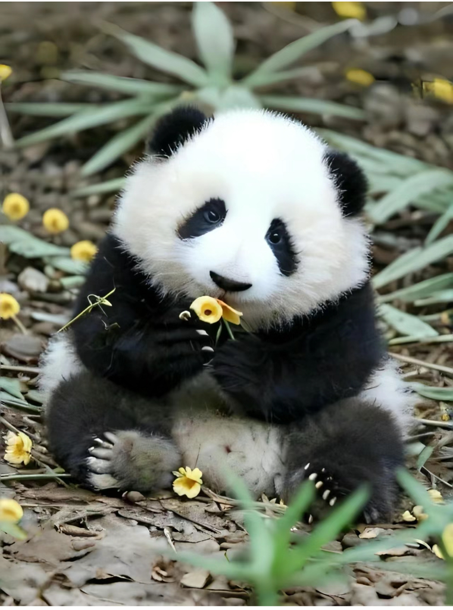

## Favorite Plot

I created different plots in the class, and here is my favorite plot that I generated before. I loved this because it was a nice visualization.

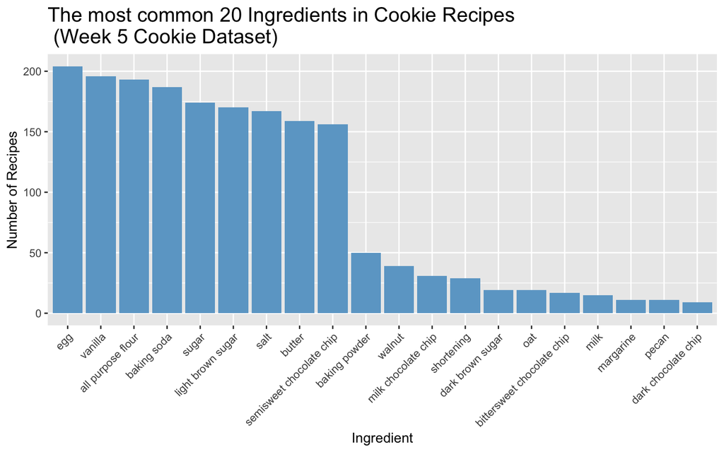

## CV Link

Click HERE to view my CV.